# Getting Started Guide for pelotonR

Laura Ellis

06 July, 2020

[figure not shown]

# About the Package

The pelotonR package was created to provide users with simple access to the Peloton API through R.

The Peloton APIs are unsupported. However, [there are some really great unofficial swagger docs](https://app.swaggerhub.com/apis/DovOps/peloton-unofficial-api/0.2.3) which I used to familiarize myself with the API.

The package offers a set of easy to use functions which allow the user to:

- Pull general Peloton data in a variety of formats
- Authenticate with the Peloton API
- Pull user specific data in a variety of formats when authenticated.
- Gather full data sets in one function call without having to handle paged API calls.
- Gather joined data sets in one function call.

# Load the Libraries

Before we start exploring the pelotonR package, we will load a few libraries used to help explore and display the data.

```r
#Uncomment the line below if you also need to install pelotonR
# devtools::install_github("lgellis/pelotonR")
library("pelotonR")
#Packages for nice output display
library(DT) # For table display
library(Hmisc) # For list display
library(tidyverse) # For data munging
library(lubridate) # For dates
library(gameofthrones) # For colors
```

# Unauthenticated API Calls

The following functions are available without authentication.

## Get Peloton Metadata Mappings Data Frame

The function `get_metadata_mapping_df(type)` allows us to see all metadata mapping for a particular category of Peloton metadata. Available options for `type` include: ‘instructors’, ‘class_types’, ‘equipment’, ‘fitness_disciplines’, device_type_display_names’, ‘content_focus_labels’, ‘difficulty_levels’, ‘locales’

To learn about the function, execute the command `?get_metadata_mapping_df`

```r
class_types <- get_metadata_mapping_df('class_types')

#Nicely display data
datatable(class_types, extensions = "Scroller", width = 1000, options = list(scrollY = 400, scroller = TRUE, scrollX = 600, pageLength = 5))
```

|  | class_types.id | class_types.name | class_types.display_name | class_types.fitness_discipline | class_types.is_active | class_types.list_order | meta_type |
| --- | --- | --- | --- | --- | --- | --- | --- |
| 1 | a5953fd181914f4eb69e755e1fefffce | Family Cardio | Family | cardio | True | 1 | class_types |
| 2 | 1fef162e27b4413facff77cc7f766ced | Dance Cardio | Dance Cardio | cardio | True | 2 | class_types |
| 3 | 6590f6042e8e4d1d8c2f3f1a73cf1729 | Theme (Bootcamp) | Theme | circuit | True | 3 | class_types |
| 4 | b0a7fc01affb4249aca872a046c6a344 | Bodyweight (Bootcamp) | Bodyweight | circuit | True | 4 | class_types |
| 5 | 209458d0f8c84614aa96537f7fff403f | Walking Bootcamp | Low Impact | circuit | True | 5 | class_types |
| 6 | 3c65fba3c4a64e2db9a12776e09bc883 | Body Focus (Bootcamp) | Body Focus | circuit | True | 6 | class_types |
| 7 | b70f0feabd7043cfa1c5f7e9f73b43d5 | Heart Rate Bootcamp | Heart Rate Zone | circuit | True | 7 | class_types |
| 8 | 919794060b734915b13ddee4e7e39084 | Running Skills | Running Skills | running | True | 8 | class_types |
| 9 | c0681493aaeb4029b01f64a6c9ff3e0e | Warm Up/Cool Down Running | Warm Up/Cool Down | running | True | 9 | class_types |
| 10 | feda7eed0d8247f2868314eaa74f37fd | Fun Run | Fun Run | running | True | 10 | class_types |

[output cut: 99 more lines]

## Get Peloton Live Rides Data Frame

The function `get_live_rides_df` returns a data frame with all of the currently available live rides.

To learn about the function, execute the command `?get_live_rides_df`

```r
live_rides <- get_live_rides_df()

#Nicely display data
datatable(live_rides, extensions = "Scroller", width = 1000, options = list(scrollY = 400, scroller = TRUE, scrollX = 600, pageLength = 5))
```

|  | id | ride_id | server_time | scheduled_start_time | start_time | end_time | pedaling_start_time | pedaling_end_time | status | countdown | is_live | is_studio | is_encore | seconds_since_start | created_at | total_workouts | is_complete | total_home_reservations | authed_user_reservation_id |
| --- | --- | --- | --- | --- | --- | --- | --- | --- | --- | --- | --- | --- | --- | --- | --- | --- | --- | --- | --- |
| 1 | e1a330808dd14dfbab414a865da96091 | 24dd4940f30e4ae7a2283061ff143f52 | 1594044938 | 1594033200 | 1594033200 | 1594035206 | 1594033260 | 1594035060 | COMPLETE |  | True | False | True |  | 1593181837 | 604 | True | 928 |  |
| 2 | 7446bc8245f842b08e9efe02e6787245 | 5689de63560947f6984707ae4d19581b | 1594044938 | 1594036800 | 1594036800 | 1594037123 | 1594036801 | 1594037101 | COMPLETE |  | True | False | True |  | 1593178302 | 56 | True | 135 |  |
| 3 | 3140d8bc3c04461d8678f05820787a15 | 6175fd5cbd0348cc9eb4d847383eb7ad | 1594044938 | 1594040400 | 1594040400 | 1594041726 | 1594040460 | 1594041660 | COMPLETE |  | True | False | True |  | 1593178331 | 813 | True | 830 |  |
| 4 | da5a1a4703304377bb09a2b24539ee22 | 46743ce495664b30b776b0736597e0be | 1594044938 | 1594040400 | 1594040400 | 1594042372 | 1594040460 | 1594042260 | COMPLETE |  | True | False | True |  | 1593178313 | 64 | True | 146 |  |
| 5 | 3a1afa32ded7476586efd1a0df9dc9b9 | 53b4dae67d1d442cbe467c6aa379f30b | 1594044938 | 1594044000 | 1594044000 | 1594044706 | 1594044060 | 1594044660 | COMPLETE |  | True | False | True |  | 1593178363 | 239 | True | 326 |  |
| 6 | 35ff08f5f0c54eb191912b4e2a421814 | 4c9e97c2df8644ba9d38f94f2645caa1 | 1594044938 | 1594047600 | 1594047600 | 1594049566 | 1594047660 | 1594049460 | PRE_START |  | True | False | True |  | 1593178401 | 0 | False | 774 |  |
| 7 | 3f65c955853b4f209cbf765319cad3ab | 8de4e2cb64874439b0697c4dc7f84fd1 | 1594044938 | 1594047600 | 1594047600 | 1594048986 | 1594047660 | 1594048860 | PRE_START |  | True | False | True |  | 1593178308 | 0 | False | 107 |  |
| 8 | e1f76028fbfc4df88d614ec8d9142512 | e40d7a1a69954024906379fade0399a5 | 1594044938 | 1594051200 | 1594051080 | 1594053075 | 1594051200 | 1594053000 | PRE_START |  | True | False | True |  | 1593178238 | 0 | False | 388 |  |
| 9 | 318b88ca87e94bc485acb2428c336950 | 71c03c3f57a5418e93c8abd8659c5fb3 | 1594044938 | 1594054800 | 1594054740 | 1594055431 | 1594054800 | 1594055400 | PRE_START |  | True | False | True |  | 1593178251 | 0 | False | 323 |  |
| 10 | fccd1298be784b1d8ec96043d5dc60df | 98211a31399941cc91aa165a86b2a2d1 | 1594044938 | 1594056600 | 1594056600 | 1594057991 | 1594056660 | 1594057860 | PRE_START |  | True | False | True |  | 1593178502 | 0 | False | 41 |  |

[output cut: 216 more lines]

## Get Full Set of Ride Information In a List

The function `get_ride_info_list` allows us to gather the full list of information for a particular ride.

To learn about the function, execute code `?get_ride_info_list`

```r
ride_info <- get_ride_info_list('55214456a1984c5885a087021e3f67b7')

#Nicely display data
list.tree(ride_info)
```

```
##  ride_info = list 60 (20624 bytes)
## .  class_type_ids = character 1= 7579b9edbdf9464fa19eb5
## .  content_provider = character 1= peloton
## .  content_format = character 1= video
## .  description = character 1= Efficient and effectiv
## .  difficulty_estimate = double 1= 8.0285
## .  overall_estimate = double 1= 0.9955
## .  difficulty_rating_avg = double 1= 8.0285
## .  difficulty_rating_count = integer 1= 26036
## .  difficulty_level = NULL 0
## .  duration = integer 1= 900
## .  equipment_ids = list 0
## .  equipment_tags = list 0
## .  ...   and 48 more
```

## Get Peloton Ride Data Frame

The function `get_ride_info_df` allows us to gather the basic ride information for a particular ride into a data frame.

To learn about the function, execute the command `?get_ride_info_df

```r
ride_info <- get_basic_ride_info_df('55214456a1984c5885a087021e3f67b7')

#Nicely display data
datatable(ride_info, extensions = "Scroller", width = 1000, options = list(scrollY = 75, scroller = TRUE, scrollX = 600, pageLength = 5))
```

[output not shown]

## Get Peloton Instructors Data Frame

The function `get_instructors_df` returns a data frame with all instructors and their information.

To learn about the function, execute the command ?get_instructors_df`

```r
instructors <- get_instructors_df()

#Nicely display data
datatable(instructors, extensions = "Scroller", width = 1000, options = list(scrollY = 400, scroller = TRUE, scrollX = 600, pageLength = 5))
```

|  | id | bio | short_bio | coach_type | is_filterable | is_instructor_group | is_visible | list_order | featured_profile | film_link | facebook_fan_page | music_bio | spotify_playlist_uri | background | ordered_q_and_as | instagram_profile | strava_profile | twitter_profile | quote | username | name | first_name | last_name | user_id | life_style_image_url | bike_instructor_list_display_image_url | web_instructor_list_display_image_url | ios_instructor_list_display_image_url | about_image_url | … |
| --- | --- | --- | --- | --- | --- | --- | --- | --- | --- | --- | --- | --- | --- | --- | --- | --- | --- | --- | --- | --- | --- | --- | --- | --- | --- | --- | --- | --- | --- | --- |
| 1 | b8c2734e18a7496fa146b3a42465da67 | To Aditi, yoga is a workout, a science and a worldview wrapped into a way of life. Aditi was introduced to yoga by her parents at a young age, but it wasn’t until she moved to India after college and … |  | peloton_coach | True | False | True | 5 | True |  |  |  | spotify:user:onepeloton:playlist:4GsoQbksdXb8QxDdhSJlWr | Yoga is a practice that allows us to thread together the external with the internal - the physical workings with the mental, emotional, spiritual. | [['How Do You Motivate?', 'Yoga is a direction - you are aiming for a posture. You don’t have to get there today, but you do have to start, you do have to try. When I began practicing, I could not get… |  |  |  | Practice makes progress. | aditishah | Aditi Shah | Aditi | Shah | b3ddf2fd15d8437db6d96ceb1ca43f99 | https://s3.amazonaws.com/workout-metric-images-prod/0ff6d91c3cec425882bed078aee539ae |  | https://s3.amazonaws.com/workout-metric-images-prod/5c57aa0949e1416aa983ecafafc21c61 | https://s3.amazonaws.com/workout-metric-images-prod/c53409bfcfb341c28b1c3f5583c91315 | https://s3.amazonaws.com/workout-metric-images-prod/6a7dca8299ed497784c42870a053b62f | … |
| 2 | f962a2b1b34d424cabab73bef81bc8db | Adrian is a powerhouse instructor with an unexpected tender side. A native New Yorker with bold Bronx energy, Adrian is a competitive sprinter—but he’s not all speed and strength. Adrian's lighthearte… | Adrian is a powerhouse instructor with an unexpected tender side. A native New Yorker with bold Bronx energy, Adrian is a competitive sprinter—but he’s not all speed and strength. His lighthearted sen… | peloton_coach | True | False | True | 6 | True |  |  |  | spotify:playlist:4GQfjWk3nsDkLkC13VC3KR | Working out should feel good! My goal is to empower people to form healthy habits to carry with them for the rest of their lives. I will challenge you, then hit you with positivity. At the end of the … | [['How Do You Motivate?', 'I encourage you to embrace being uncomfortable. That’s where growth happens. I try not to take myself too seriously, though. My workouts are tough, but I like to lead with h… |  |  |  | “Never give up because great things take time.” | nooneissafe | Adrian Williams | Adrian | Williams | 8bb5f9c485a543c681e903bf9bb01019 | https://s3.amazonaws.com/workout-metric-images-prod/470ba0ef2d9d4cc5b9c2b08f0defa992 |  | https://s3.amazonaws.com/workout-metric-images-prod/7903cf40df6b451a957f65819050a0b4 | https://s3.amazonaws.com/workout-metric-images-prod/a4bdedc9b6974de9983ebea0e49b82d0 | https://s3.amazonaws.com/workout-metric-images-prod/924cc5495ca14904a72b8067eb39be64 | … |
| 3 | a8c56f162c964e9392568bc13828a3fb | When Anna first turned to yoga, she felt a switch turn on inside of her. As she built a deeper connection with her mind and body, she began accomplishing things she never knew possible. Moved to share… | “Look for balance but always be willing to fall” | peloton_coach | True | False | True | 7 | True |  |  |  | spotify:user:onepeloton:playlist:4VFujVb67VlWFfSrz3BcWl | My classes combine heat building movement with precise, focused instruction for Members to find stability and space in their bodies and minds. Watching Members grow and thrive on the mat and in their … | [['How Do You Motivate?', 'I aim to inspire people to do their best and let go of the results. Yoga is not a competition or performance, it’s just for you (how great is that?). It’s a tool to strength… |  |  |  | Look for balance but always be willing to fall. | agreenberg | Anna Greenberg | Anna | Greenberg | 026d817a66704ea6b5bc148ba0b803f7 | https://s3.amazonaws.com/workout-metric-images-prod/b07a4ad3f0504d589f13d760ce010cd3 |  | https://s3.amazonaws.com/workout-metric-images-prod/a423930b36cc4794b1d1ea836f33768c | https://s3.amazonaws.com/workout-metric-images-prod/3c7b43033049475b9b3b95d67848c683 | https://s3.amazonaws.com/workout-metric-images-prod/76f3fbaa9c6448579f7d0d9bed8a5b53 | … |
| 4 | 2e57092bee334c8c8dcb9fe16ba5308c | Alex Toussaint has a love for fitness, teamwork and discipline rooted in his military school background. With his eye always on the prize, Alex uses the power of positivity to motivate Members to conf… | "Feel good. Look good. Do better! … Trust the Process!" | peloton_coach | True | False | True | 9 | True |  | https://www.facebook.com/alextoussaintfitness/ | Check out a sample of Alex’s current class playlist. | spotify:user:onepeloton:playlist:77bxh3Xw9h5tHOrNv5Zkj7 | I approach all my classes like it might be my last one. Watching Members become the best version of themselves truly inspires me to give it my all every ride I teach. | [['How Do You Motivate?', 'Using my military background, I push my Members to their full potential at all times. I want Members to approach my workout like an athlete, and leave feeling like a champio… |  |  |  | Feel good. Look good. Do better! … Trust the Process! | AlexToussaint | Alex Toussaint | Alex | Toussaint | f42d9968258c4877b8aea54cbe51ad77 | https://s3.amazonaws.com/workout-metric-images-prod/ed338e46f7e746409a7e0a2d28ddedda |  | https://s3.amazonaws.com/workout-metric-images-prod/43350a0e581d45f0bf1a98f18f26b637 | https://s3.amazonaws.com/workout-metric-images-prod/8af7ac20ff26473093c47c84c71c7894 | https://s3.amazonaws.com/workout-metric-images-prod/a914e36fa78046bd9d078352831ddad9 | … |
| 5 | 731d7b7f6b414a49892c21f01e25317d | As a model, dancer, certified health coach, host of the Brooklyn Nets, runner, and the founder of fitness lifestyle brand Love Squad, Ally really does it all. At Peloton as in all of her pursuits, All… | They say the early bird gets the worm, but the early bird only gets whatever is left over from the hustlers. | peloton_coach | True | False | True | 10 | True |  | https://www.facebook.com/allylovepeloton/ | Check out a sample of Ally’s current class playlist. | spotify:user:onepeloton:playlist:3bIq6eu3XKCU3Qc6dp37gu | My life goal is to remind the world that we all have one life to live, and together we should live it to the fullest. I believe that what connects us most is the power of sweat, and physically working… | [['How Do You Motivate?', 'We ride to become boss of the Bike and to remind ourselves that we are the boss of our lives. My classes are designed to make you feel proud and uplifted, both on and off th… |  |  |  | They say the early bird gets the worm, but the early bird only gets whatever is left over from the hustlers. | AllyMissLove | Ally Love | Ally | Love | 2c094f455ec64611baf612dfdef1f6a7 | https://s3.amazonaws.com/workout-metric-images-prod/5b812e410b5a4ab4b8573ab2b1e2b5ad |  | https://s3.amazonaws.com/workout-metric-images-prod/747e496370f04f89a71a288ba781a3d5 | https://s3.amazonaws.com/workout-metric-images-prod/2b1027db53cc48c0bcc2e999ac224ae8 | https://s3.amazonaws.com/workout-metric-images-prod/c9dc8874b5f5431cb49e57fcfd09abf4 | … |
| 6 | c9fa21c2004c4544a7c35c28a6196c77 | Andy takes a technique-centered approach to fitness, drawing on his experience as an accomplished former gymnast and pole vaulter in his home state of Connecticut. A celebrated personal trainer in NYC… | "Fight Fatigue with Focus." | peloton_coach | True | False | True | 11 | True |  | https://www.facebook.com/AndySpeerPeloton/ |  | spotify:user:onepeloton:playlist:1TuJLkF4s4n0g6Q7rgFKno | My inspiration for teaching is rooted in helping others improve their lives through fitness, as other coaches have done for me, now it’s my turn to pay it forward. | [['How Do You Motivate?', 'I want members to approach my class with an intent to be challenged and grow. I focus on technique and ensure that there is a purpose behind everything I ask of you.'], ['Ou… |  |  |  | Fight Fatigue with Focus. | ASpeer | Andy Speer | Andy | Speer | 1983bc74b89c403db8876500b1895573 | https://s3.amazonaws.com/workout-metric-images-prod/8411c574a4104025ab2916d8ee54edab |  | https://s3.amazonaws.com/workout-metric-images-prod/afd27714abe24e0dacf95ee18d0c9a8e | https://s3.amazonaws.com/workout-metric-images-prod/5e572b684c0a456cb8fe98583753c655 | https://s3.amazonaws.com/workout-metric-images-prod/69b41ec59e9447668b6ab8dd9ee9673a | … |
| 7 | 286fc17080d34406a54b80ad8ff83e12 | Becs joins Peloton from London as an accomplished distance runner and coach who uses the sport as a way to explore the world. From adventurous trails, tropical beaches, and exotic volcanoes, to sub-3:… | "Challenge yourself, and be determined to thrive." | peloton_coach | True | False | True | 12 | True |  | https://www.facebook.com/becsgentrypeloton/ |  | spotify:user:onepeloton:playlist:25hvBDM2UA8X9EZqvsA51k?si=6OGJiiQiQbqyUkbi3_QRAw | My inspiration comes from running all around the world! I want to teach the people in my class to love the way running makes them feel. My approach is tough, but I’ll always run with a smile because m… | [['How Do You Motivate?', 'I share a lot of my own personal training experiences to relate to people in my classes. I want Members to see that we have the same goals, and are on a journey together.'],… |  |  |  | Challenge yourself, and be determined to thrive. | BecsGentry | Becs Gentry | Becs | Gentry | 81be40879cf34e4581e1840d217146e3 | https://s3.amazonaws.com/workout-metric-images-prod/adc7373b2e734f09a97ca51c3bfc5da6 |  | https://s3.amazonaws.com/workout-metric-images-prod/f330cae7b2bd49d7b7300c35ba479f7e | https://s3.amazonaws.com/workout-metric-images-prod/37913816c8d94c3ea00a1fb941bea157 | https://s3.amazonaws.com/workout-metric-images-prod/b9bbff07102b4a3ab9ade5b328372db6 | … |
| 8 | 7f3de5e78bb44d8591a0f77f760478c3 | Growing up, Ben was an accomplished athlete who was always looking for the opportunity to run, ride, kick a ball or compete. Working at a prestigious finance firm, Ben found himself daydreaming about … | Work hard in silence, let progress be your noise. | peloton_coach | True | False | True | 13 | True |  |  |  | spotify:user:onepeloton:playlist:1APNxztsymOZZyGm9wsA2Y | I love fitness because it has a wonderful way of breaking down barriers for people. | [[' How Do You Motivate?\r\n', 'I love having the opportunity to change someone’s mindset and self-belief. I love to inspire. I love to educate people so they feel fully in control of their own progre… |  |  |  | Work hard in silence, let progress be your noise. | ChampionSpirit | Ben Alldis | Ben | Alldis | 085884a8a402401087043f4f1be5ac90 | https://s3.amazonaws.com/workout-metric-images-prod/1f6cea8813aa404eba9dbc62bfdfb158 |  | https://s3.amazonaws.com/workout-metric-images-prod/884a3bfff79c4e9dbf3f14d42df10a59 | https://s3.amazonaws.com/workout-metric-images-prod/0fdd04214ba944568c937ca730662e5f | https://s3.amazonaws.com/workout-metric-images-prod/8607efdd5bed48038579d25dcee46143 | … |
| 9 | 1423df9e4ad64a84a3044d20a5c36563 | Growing up in a household of athletes in Chicago and majoring in kinesiology in college, Chase knew that fitness and movement would play a big role in his life. It was while working in physical therap… | "It’s what you do in the dark that puts you in the light." | peloton_coach | True | False | True | 14 | True |  | https://www.facebook.com/chasetuckerpeloton/ |  | spotify:user:onepeloton:playlist:1wronrrPSROrD12FoQBFvs?si=a2qTQrYgTRiuaOKLclgx8A | I want Members to approach my workouts by looking at the big picture. Our time together will be so much deeper than just “working out” or “being fit.” It will be about showing up to conquer what’s in … | [['How Do You Motivate?', 'I want Members to approach my workouts as so much more than just that. This is so much deeper than just “working out” or “being fit.”'], ['Outside of Peloton', 'I’m always l… |  |  |  | It’s what you do in the dark that puts you in the light. | pelotonchase | Chase Tucker | Chase | Tucker | af6fc97edfba4ac0b53078ae48a6d19f | https://s3.amazonaws.com/workout-metric-images-prod/d4f3dfe82f62455b9cfce79f4e669dee |  | https://s3.amazonaws.com/workout-metric-images-prod/560a2c8f914b46eda8973308d71410f7 | https://s3.amazonaws.com/workout-metric-images-prod/116eed9082614621918e8f30bd2e9bb1 | https://s3.amazonaws.com/workout-metric-images-prod/af4bae26e69340e6806c8731018a1f4d | … |
| 10 | 0021e2220a7940cf94a7647b1e4bae6c | Chelsea has traveled a unique path to bring her expression of yoga to both the tenured yogi and those who never believed the practice was for them. Chelsea received her Ph.D. in Educational Studies, m… | Chelsea believes that practicing yoga connects you more deeply to yourself and the world around you. Her teaching style is creative, challenging and compassionate, making you feel at home with her whi… | peloton_coach | True | False | True | 15 | True |  |  |  | spotify:playlist:5Yi3AWNN0h9IW96t37HEHj | My intention is to create an environment that leaves Members with a strong sense of belonging and accomplishment. I am inspired by how yoga, music and soulful storytelling can take us on a journey clo… | [['How Do You Motivate?', 'I empower you to embrace the body you are in! Yoga is an opportunity to pour love back into yourself, and can travel with you off the mat and into your life in the form of s… |  |  |  | I want to be someone people relate to. I’ll encourage you as I push you. | CJRLovesYoga | Chelsea Jackson Roberts | Chelsea | Jackson Roberts | 992dcb9c3fa04c9a8493556512e83254 | https://s3.amazonaws.com/workout-metric-images-prod/04cd2d36bc5e4869b139de6a8a1ab6be |  | https://s3.amazonaws.com/workout-metric-images-prod/a7ad8aeef1b048c98a22652e8316fef9 | https://s3.amazonaws.com/workout-metric-images-prod/d37f8977a5624c76a6fdb5803eb99eb7 | https://s3.amazonaws.com/workout-metric-images-prod/06a190c517624debbd6780ef03d67247 | … |

[output cut: 24 more lines]

## Get Live Rides and Details

The function `get_live_ride_and_details_df` returns a data frame with all current live rides as well as the joined ride and instructor data for each ride.

To learn about the function, execute the command `?get_live_ride_and_details_df`

```r
live_with_details <- get_live_ride_and_details_df()

#Nicely display data
datatable(live_with_details, extensions = "Scroller", width = 1000, options = list(scrollY = 400, scroller = TRUE, scrollX = 600, pageLength = 5))
```

|  | id | ride_id | server_time | scheduled_start_time | start_time | end_time | pedaling_start_time | pedaling_end_time | status | countdown | is_live | is_studio | is_encore | seconds_since_start | created_at | total_workouts.x | is_complete | total_home_reservations | authed_user_reservation_id | description | difficulty_estimate | difficulty_rating_avg | difficulty_rating_count | instructor_id | length | location | overall_rating_avg | overall_rating_count | is_explicit | … |
| --- | --- | --- | --- | --- | --- | --- | --- | --- | --- | --- | --- | --- | --- | --- | --- | --- | --- | --- | --- | --- | --- | --- | --- | --- | --- | --- | --- | --- | --- | --- |
| 1 | e69a3dba05f44dbea9905f45b271c8b4 | 00bdcfd5290f4d8fb9891204b5c3b922 | 1594044942 | 1594315800 | 1594315800 | 1594317784 | 1594315860 | 1594317660 | PRE_START |  | True | False | True |  | 1593713401 | 0 | False | 126 |  | Split your workout 50/50 between cardio on the Tread and strength training on the floor to the perfect pop playlist. | 0 | 0 | 0 | f962a2b1b34d424cabab73bef81bc8db | 1984 | psny-studio-4 | 0 | 0 | True | … |
| 2 | 04b78c8c85f949f78c6301834da88561 | 0101f40acc104df1951fa7946a2e9adf | 1594044942 | 1594251900 |  |  |  |  | PRE_START |  | True | False | False |  | 1593710168 | 0 | False | 465 |  | Join this cardio workout designed to increase strength and endurance. | 0 | 0 | 0 | 1b79e462bd564b6ca5ec728f1a5c2af0 | 0 | psny-studio-4 | 0 | 0 | False | … |
| 3 | 403e9094e54b4f549df7e0fdd5a01c5b | 014abe807a7e4fdf8d0d5f1f1133dca6 | 1594044942 | 1594587600 | 1594587600 | 1594589582 | 1594587660 | 1594589460 | PRE_START |  | True | False | True |  | 1593713640 | 0 | False | 107 |  | Shake off the week with Jess King and DJ John Michael. With laugh-out-loud moments and surprises at every turn, this 30-minute ride is the most fun you’ll have on the Bike! | 8.1339 | 8.1339 | 11158 | 048f0ce00edb4427b2dced6cbeb107fd | 1982 | us-bike-remote-broadcast | 8.1339 | 13487 | False | … |
| 4 | 796f4e3a7ce74dabbc9fda47e84c297c | 027a50eceaf943e4a0270e779ea1c7cb | 1594044942 | 1594576800 | 1594576800 |  |  |  | PRE_START |  | True | False | True |  | 1593761254 | 0 | False | 47 |  | Hop on the Bike to dance and work your way through this 2000s-themed ride. | 0 | 0 | 0 | 3ff679ebbd324c83a8ab6cfa6bb4be37 | 0 | uk | 0 | 0 | False | … |
| 5 | 83ad6f29de6243b5a808d01635b7a706 | 029019cb603041a6b6ca3a55ce3ddf26 | 1594044942 | 1594222200 |  |  |  |  | PRE_START |  | True | False | False |  | 1593700412 | 0 | False | 750 |  | Efficient and effective, this intervals-driven class boosts metabolism and gives you a heart-healthy workout leaving you full of energy and confidence. | 0 | 0 | 0 | c406f36aa2a44a5baf8831f8b92f6920 | 0 | psny-studio-1 | 0 | 0 | False | … |
| 6 | c50fab0a2810484b96dd62ffa9ca2ef7 | 036d75dfe7d44e919c9c74d5998e48fb | 1594044942 | 1594135800 |  |  |  |  | PRE_START |  | True | False | False |  | 1593713124 | 0 | False | 0 |  | Count yourself in for Peloton's first ever cycling-to-yoga series! Hop off the Bike and onto the mat in this all levels yoga class with Denis. Flow from one pose to the next, and reset your mindset by… | 0 | 0 | 0 | 1e59e949a19341539214a4a13ea7ff01 | 0 | psny-studio-2 | 0 | 0 | False | … |
| 7 | 3048ef20eabd43cc98e7541cec2edf26 | 05152ab01c6f43a99604c9a90a04590f | 1594044942 | 1594287000 |  |  |  |  | PRE_START |  | True | False | False |  | 1593600490 | 0 | False | 0 |  | Tease your hair and grab your leg warmers to meet us on the Bike for this fun, 80s themed ride. | 0 | 0 | 0 | 7f3de5e78bb44d8591a0f77f760478c3 | 0 | uk | 0 | 0 | False | … |
| 8 | bb9f50ebef664901850786d670d1c099 | 059eceaa7f4245688e34beb93d17d489 | 1594044942 | 1594125900 |  |  |  |  | PRE_START |  | True | False | False |  | 1593713071 | 0 | False | 205 |  | This Yoga Flow class focuses on poses that engage, strengthen and open up the muscles of the lower body. | 0 | 0 | 0 | 0021e2220a7940cf94a7647b1e4bae6c | 0 | psny-studio-2 | 0 | 0 | False | … |
| 9 | 5e5a61051dda48afb56cd52f46353d6e | 06ceff9e059c4b3096b23d7a557f90f4 | 1594044942 | 1594324800 |  |  |  |  | PRE_START |  | True | False | False |  | 1593713814 | 0 | False | 26 |  | A slower-paced Yoga Flow, with poses modified as appropriate for expecting mothers. | 0 | 0 | 0 | f48347e0fb3748c08aa6c6e031b48897 | 0 | psny-studio-2 | 0 | 0 | False | … |
| 10 | 512b4f345dbc4e628b3430e6d6950648 | 073a9023e1c04264805f0f2a652f5864 | 1594044942 | 1594385100 |  |  |  |  | PRE_START |  | True | False | False |  | 1593712599 | 0 | False | 0 |  | Give your muscles the love and care they need after a challenging run so they can be fresh and ready for your next workout. | 0 | 0 | 0 | 286fc17080d34406a54b80ad8ff83e12 | 0 | psny-studio-4 | 0 | 0 | False | … |

[output cut: 208 more lines]

### Plot Ride Data

Now that we have a data frame with all live rides and their metadata, we will do a simple plot to display some of the details of the live rides available. In this example, we are plotting the count of live rides by instructor.

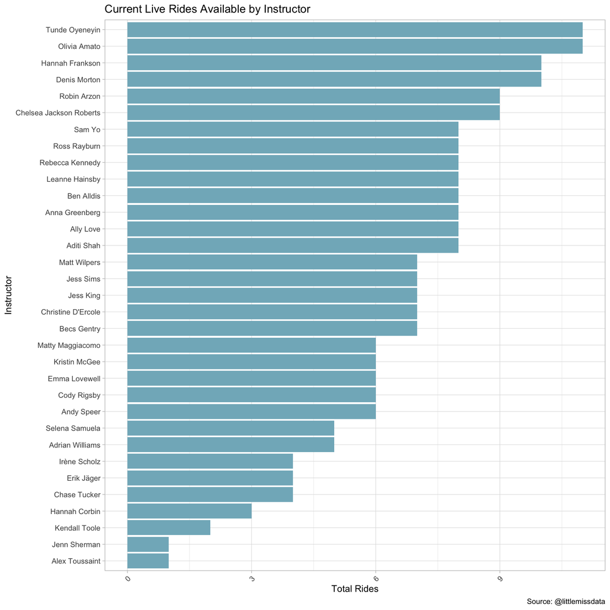

```r
p <- live_with_details %>%
  dplyr::group_by(instructor.name) %>%
  dplyr::summarize(N = length(instructor.name)) %>%
  dplyr::filter(instructor.name !='NA') %>%
  ggplot(aes(y=reorder(instructor.name, N), N) ) +
  geom_bar(stat = "identity", fill= "#82B5C4") +
  theme_light() +
  theme(axis.text.x = element_text(angle = 45, hjust = 1), legend.position="bottom") +
  labs(title = "Current Live Rides Available by Instructor",
       x = "Total Rides", y = "Instructor",
       caption = 'Source: @littlemissdata')
p
```

# Authenticate with Peloton

The function `authenticate(username, password)` allows the user to authenticate with the Peloton API. In this function you are able to pass in your `username` and `password`. If you pass in no value, the system will prompt you for a user name and password.

To learn about the function, execute the command `?authenticate`

```r
auth_response <-authenticate()
```

```
## Please enter password in TK window (Alt+Tab)
## Please enter password in TK window (Alt+Tab)
```

```r
head(summary(auth_response))
```

```
##    Length     Class      Mode
##         1      json character
```

# Authenticated API Calls

The following functions are only available after the user has authenticated with the Peloton API. Authentication is easily done by calling the `authenticate()` function documented above.

## Get My Workout Stats Data Frame

The function `get_my_workout_stats_df()` will gather the workout counts by category for the current authenticated user.

To learn about the function, execute the command `?get_my_workout_stats_df`

```r
workout_stats <-get_my_workout_stats_df()
datatable(workout_stats, extensions = "Scroller", width = 1000, options = list(scrollY = 400, scroller = TRUE, scrollX = 600, pageLength = 5))
```

|  | name | slug | count | icon_url |
| --- | --- | --- | --- | --- |
| 1 | Strength | strength | 138 | https://s3.amazonaws.com/static-cdn.pelotoncycle.com/workout-count-icons/nonzero-strength2.png |
| 2 | Bootcamp | circuit | 0 | https://s3.amazonaws.com/static-cdn.pelotoncycle.com/workout-count-icons/zero-circuit2.png |
| 3 | Meditation | meditation | 1 | https://s3.amazonaws.com/static-cdn.pelotoncycle.com/workout-count-icons/nonzero-meditation2.png |
| 4 | Cycling | cycling | 187 | https://s3.amazonaws.com/static-cdn.pelotoncycle.com/workout-count-icons/nonzero-cycling2.png |
| 5 | Running | running | 0 | https://s3.amazonaws.com/static-cdn.pelotoncycle.com/workout-count-icons/zero-running2.png |
| 6 | Yoga | yoga | 0 | https://s3.amazonaws.com/static-cdn.pelotoncycle.com/workout-count-icons/zero-yoga2.png |
| 7 | Cardio | cardio | 4 | https://s3.amazonaws.com/static-cdn.pelotoncycle.com/workout-count-icons/nonzero-cardio2.png |
| 8 | Stretching | stretching | 1 | https://s3.amazonaws.com/static-cdn.pelotoncycle.com/workout-count-icons/nonzero-stretching2.png |
| 9 | Walking | walking | 0 | https://s3.amazonaws.com/static-cdn.pelotoncycle.com/workout-count-icons/zero-walking2.png |

### Plot Workout Stats Data Frame

When you get your workout stats using `get_my_workout_stats_df()`, you can plot a simple bar chart with ggplot2.

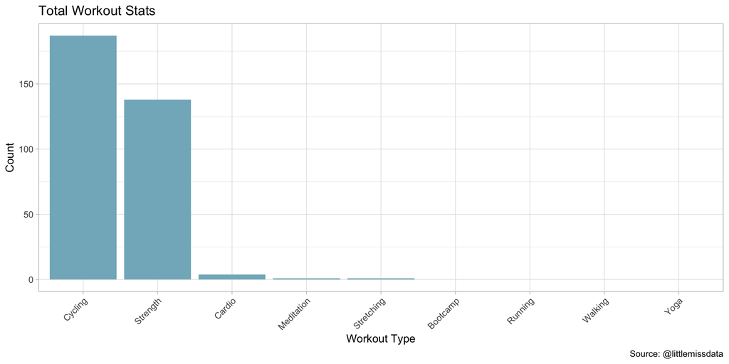

```r
g <- workout_stats %>%
  ggplot(aes(x=factor(reorder(name, -count)), y=count)) +
  geom_bar(stat="identity", fill= "#82B5C4") +
  theme_light() +
  theme(axis.text.x = element_text(angle = 45, hjust = 1)) +
  labs(title = "Total Workout Stats",
       x = "Workout Type", y = "Count",
       caption = 'Source: @littlemissdata')
g
```

## Get My Stats List

The function `get_my_stats_list()` will gather all stats for the current authenticated user and return the results in a list.

To learn about the function, execute the command `?get_my_stats_list`

```r
stats <-get_my_stats_list()
head(summary(stats))
```

```
##                          Length Class  Mode
## facebook_id              0      -none- NULL
## total_workouts           1      -none- numeric
## weight                   1      -none- numeric
## total_followers          1      -none- numeric
## default_heart_rate_zones 5      -none- numeric
## id                       1      -none- character
```

## Get My Workouts Data Frame

The function `get_workouts_df()` allows the user to gather all individual workouts for a specified user and return the results in a data frame. Note that if no user_id is passsed in, it will use the user id for the authenticated user. You can also pass in a specified user id. For example: `get_workouts_df('n7u2739e18a7496fa146b3a42465da78')`.

To learn about the function, execute the command `?get_workouts_df`

```r
workouts <-get_workouts_df()

#Drop personal information
workouts <- workouts%>%
  dplyr::mutate(user_id = NULL)

#Nicely display data
datatable(workouts, extensions = "Scroller", width = 1000, options = list(scrollY = 400, scroller = TRUE, scrollX = 600, pageLength = 5))
```

|  | created_at | device_type | end_time | fitbit_id | fitness_discipline | has_pedaling_metrics | has_leaderboard_metrics | id | is_total_work_personal_record | metrics_type | name | peloton_id | platform | start_time | strava_id | status | timezone | title | total_work | workout_type | total_video_watch_time_seconds | total_video_buffering_seconds | peloton.ride.has_closed_captions | peloton.ride.content_provider | peloton.ride.content_format | peloton.ride.description | peloton.ride.difficulty_rating_avg | peloton.ride.difficulty_rating_count | peloton.ride.difficulty_level | … |
| --- | --- | --- | --- | --- | --- | --- | --- | --- | --- | --- | --- | --- | --- | --- | --- | --- | --- | --- | --- | --- | --- | --- | --- | --- | --- | --- | --- | --- | --- | --- |
| 1 | 1593981820 | home_bike_v1 | 1593984016 |  | cycling | True | False | 4e15ea163ba54e028f00fe427e70f65d | False | cycling | Cycling Workout |  | home_bike | 1593981820 |  | COMPLETE | America/Chicago | 36 min 36 sec Just Ride | 108869.95 | freestyle | 0 | 0 |  |  |  |  |  |  |  | … |
| 2 | 1593981742 | home_bike_v1 | 1593981783 |  | cycling | True | False | 4a84e6e6538a4cb68f329cd840052081 | False | cycling | Cycling Workout |  | home_bike | 1593981742 |  | COMPLETE | America/Chicago | 41 sec Just Ride | 1709.36 | freestyle | 0 | 0 |  |  |  |  |  |  |  | … |
| 3 | 1593796420 | home_bike_v1 | 1593797080 |  | strength | False | False | 28bb85f7c3ef49f68dbd5cef2003b828 | False |  | Strength Workout | e997205f3197450cbc5eaba8b28b94e8 | home_bike | 1593796482 |  | COMPLETE | America/Chicago |  | 0 | class | 630 | 1 | False | peloton | video | Grab your free weights from the back of the Bike to tone your arms during your workout. | 7.4228 | 23941 | intermediate | … |
| 4 | 1593794375 | home_bike_v1 | 1593796235 |  | cycling | True | True | a2da3360bcb8459a9eae4c6641e56bf6 | False | cycling | Cycling Workout | 40cc10cb754a48b18a7fd08e8372f458 | home_bike | 1593794436 |  | COMPLETE | America/Chicago |  | 181389.28 | class | 1831 | 0 | False | peloton | video | We dare you not to dance through this new tracks theme ride focusing on the latest and greatest on the charts. | 8.4212 | 19182 |  | … |
| 5 | 1593640953 | home_bike_v1 | 1593642812 |  | cycling | True | True | b41da18813ea4e289d033d16a8610545 | False | cycling | Cycling Workout | f4094c1b97714aa187e8cc8e3ecc0f52 | home_bike | 1593641014 |  | COMPLETE | America/Chicago |  | 163953.56 | class | 1831 | 0 | False | peloton | video | Move with Pride in this 30-minute ride with Cody! | 8.2717 | 38099 |  | … |
| 6 | 1593475215 | home_bike_v1 | 1593476474 |  | cycling | True | True | 5c4756fc592c467581336e133ea89669 | False | cycling | Cycling Workout | 4453fd44d7e04ad29174cf5948d2cb38 | home_bike | 1593475276 |  | COMPLETE | America/Chicago |  | 109886.79 | class | 1231 | 0 | False | peloton | video | Celebrate Canada Day with classes powered by music from your favourite Canadian artists! | 7.4742 | 13118 | intermediate | … |
| 7 | 1593378622 | home_bike_v1 | 1593380481 |  | cycling | True | True | f4fdd6ded5014f5992af9282ef0aa734 | False | cycling | Cycling Workout | b68e1eb4ef2c4d37902e1ff0f059c099 | home_bike | 1593378683 |  | COMPLETE | America/Chicago |  | 145961.44 | class | 1831 | 0 | False | peloton | video | Bursts of effort integrated with free weight segments and followed by recovery, these rides challenge your mind and strengthen your body inside and out. | 8.6939 | 25026 |  | … |
| 8 | 1593289205 | iPhone | 1593289895 |  | strength | False | False | 2be7198798464fcc8481bc53d6fa8a70 | False |  | Strength Workout | fcb2001b49b74470be24f23d80cfeb4a | iOS_app | 1593289295 |  | COMPLETE | America/Chicago |  | 0 | class | 795 | 5 | False | peloton | video | Join us on the floor for a core workout to align, strengthen and tone your lower back and abdominal muscles. | 7.073 | 44018 |  | … |
| 9 | 1593288053 | home_bike_v1 | 1593288712 |  | strength | False | False | 47b5671c8d614a4d8eb47d4dd6a24af9 | False |  | Strength Workout | 4739c58c40de46bc864504354194158f | home_bike | 1593288114 |  | COMPLETE | America/Chicago |  | 0 | class | 631 | 0 | False | peloton | video | Grab your free weights from the back of the Bike to tone your arms during your workout. | 7.3329 | 25643 |  | … |
| 10 | 1593287559 | home_bike_v1 | 1593287859 |  | cycling | True | True | 612236cc011c472089d44d062404c69a | False | cycling | Cycling Workout | 7cfab5e8ab8f4806bf08cee57499f131 | home_bike | 1593287560 |  | COMPLETE | America/Chicago |  | 17653.2 | class | 271 | 0 | False | peloton | video | Take a few extra minutes after a ride to lower your heart rate and ease your body into a healthy recovery zone. | 3.9371 | 117109 | intermediate | … |

[output cut: 321 more lines]

## Get My Workouts with Instructor Information Data Frame

The function `get_workouts_and_instructors_df()` allows the user to gather all individual workouts and all related instructor data for a user and return it in a data frame. If a user id is not passed into the function, it will return the current users workouts.

To learn about the function, execute the command `?get_workouts_and_instructors_df`

```r
workouts_and_instructors <-get_workouts_and_instructors_df()

#Drop personal information
workouts_and_instructors <- workouts_and_instructors%>%
  dplyr::mutate(workout.user_id = NULL)

#Nicely display data
datatable(workouts_and_instructors, extensions = "Scroller", width = 1000, options = list(scrollY = 400, scroller = TRUE, scrollX = 600, pageLength = 5))
```

|  | workout.created_at | workout.device_type | workout.end_time | workout.fitbit_id | workout.fitness_discipline | workout.has_pedaling_metrics | workout.has_leaderboard_metrics | workout.id | workout.is_total_work_personal_record | workout.metrics_type | workout.name | workout.peloton_id | workout.platform | workout.start_time | workout.strava_id | workout.status | workout.timezone | workout.title | workout.total_work | workout.workout_type | workout.total_video_watch_time_seconds | workout.total_video_buffering_seconds | workout.peloton.ride.has_closed_captions | workout.peloton.ride.content_provider | workout.peloton.ride.content_format | workout.peloton.ride.description | workout.peloton.ride.difficulty_rating_avg | workout.peloton.ride.difficulty_rating_count | workout.peloton.ride.difficulty_level | … |
| --- | --- | --- | --- | --- | --- | --- | --- | --- | --- | --- | --- | --- | --- | --- | --- | --- | --- | --- | --- | --- | --- | --- | --- | --- | --- | --- | --- | --- | --- | --- |
| 1 | 1593981820 | home_bike_v1 | 1593984016 |  | cycling | True | False | 4e15ea163ba54e028f00fe427e70f65d | False | cycling | Cycling Workout |  | home_bike | 1593981820 |  | COMPLETE | America/Chicago | 36 min 36 sec Just Ride | 108869.95 | freestyle | 0 | 0 |  |  |  |  |  |  |  | … |
| 2 | 1593981742 | home_bike_v1 | 1593981783 |  | cycling | True | False | 4a84e6e6538a4cb68f329cd840052081 | False | cycling | Cycling Workout |  | home_bike | 1593981742 |  | COMPLETE | America/Chicago | 41 sec Just Ride | 1709.36 | freestyle | 0 | 0 |  |  |  |  |  |  |  | … |
| 3 | 1593796420 | home_bike_v1 | 1593797080 |  | strength | False | False | 28bb85f7c3ef49f68dbd5cef2003b828 | False |  | Strength Workout | e997205f3197450cbc5eaba8b28b94e8 | home_bike | 1593796482 |  | COMPLETE | America/Chicago |  | 0 | class | 630 | 1 | False | peloton | video | Grab your free weights from the back of the Bike to tone your arms during your workout. | 7.4228 | 23941 | intermediate | … |
| 4 | 1593794375 | home_bike_v1 | 1593796235 |  | cycling | True | True | a2da3360bcb8459a9eae4c6641e56bf6 | False | cycling | Cycling Workout | 40cc10cb754a48b18a7fd08e8372f458 | home_bike | 1593794436 |  | COMPLETE | America/Chicago |  | 181389.28 | class | 1831 | 0 | False | peloton | video | We dare you not to dance through this new tracks theme ride focusing on the latest and greatest on the charts. | 8.4212 | 19182 |  | … |
| 5 | 1593640953 | home_bike_v1 | 1593642812 |  | cycling | True | True | b41da18813ea4e289d033d16a8610545 | False | cycling | Cycling Workout | f4094c1b97714aa187e8cc8e3ecc0f52 | home_bike | 1593641014 |  | COMPLETE | America/Chicago |  | 163953.56 | class | 1831 | 0 | False | peloton | video | Move with Pride in this 30-minute ride with Cody! | 8.2717 | 38099 |  | … |
| 6 | 1593475215 | home_bike_v1 | 1593476474 |  | cycling | True | True | 5c4756fc592c467581336e133ea89669 | False | cycling | Cycling Workout | 4453fd44d7e04ad29174cf5948d2cb38 | home_bike | 1593475276 |  | COMPLETE | America/Chicago |  | 109886.79 | class | 1231 | 0 | False | peloton | video | Celebrate Canada Day with classes powered by music from your favourite Canadian artists! | 7.4742 | 13118 | intermediate | … |
| 7 | 1593378622 | home_bike_v1 | 1593380481 |  | cycling | True | True | f4fdd6ded5014f5992af9282ef0aa734 | False | cycling | Cycling Workout | b68e1eb4ef2c4d37902e1ff0f059c099 | home_bike | 1593378683 |  | COMPLETE | America/Chicago |  | 145961.44 | class | 1831 | 0 | False | peloton | video | Bursts of effort integrated with free weight segments and followed by recovery, these rides challenge your mind and strengthen your body inside and out. | 8.6939 | 25026 |  | … |
| 8 | 1593289205 | iPhone | 1593289895 |  | strength | False | False | 2be7198798464fcc8481bc53d6fa8a70 | False |  | Strength Workout | fcb2001b49b74470be24f23d80cfeb4a | iOS_app | 1593289295 |  | COMPLETE | America/Chicago |  | 0 | class | 795 | 5 | False | peloton | video | Join us on the floor for a core workout to align, strengthen and tone your lower back and abdominal muscles. | 7.073 | 44018 |  | … |
| 9 | 1593288053 | home_bike_v1 | 1593288712 |  | strength | False | False | 47b5671c8d614a4d8eb47d4dd6a24af9 | False |  | Strength Workout | 4739c58c40de46bc864504354194158f | home_bike | 1593288114 |  | COMPLETE | America/Chicago |  | 0 | class | 631 | 0 | False | peloton | video | Grab your free weights from the back of the Bike to tone your arms during your workout. | 7.3329 | 25643 |  | … |
| 10 | 1593287559 | home_bike_v1 | 1593287859 |  | cycling | True | True | 612236cc011c472089d44d062404c69a | False | cycling | Cycling Workout | 7cfab5e8ab8f4806bf08cee57499f131 | home_bike | 1593287560 |  | COMPLETE | America/Chicago |  | 17653.2 | class | 271 | 0 | False | peloton | video | Take a few extra minutes after a ride to lower your heart rate and ease your body into a healthy recovery zone. | 3.9371 | 117109 | intermediate | … |

[output cut: 321 more lines]

### Create some Fun Graphs

#### Progress Line Chart

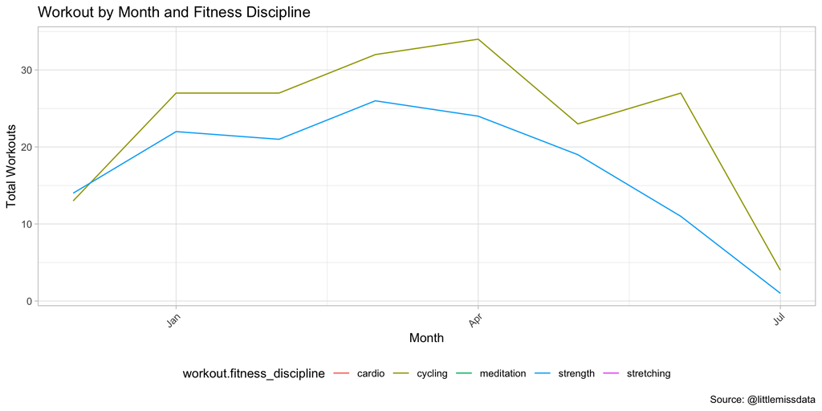

```r
p <- workouts_and_instructors %>%
  dplyr::group_by(workout.start_month, workout.fitness_discipline) %>%
  dplyr::summarize(N = length(workout.fitness_discipline)) %>%
  ggplot(aes(x=workout.start_month, y=N, color=workout.fitness_discipline) ) +
  geom_line() +
  scale_fill_got(discrete = TRUE, option = "Margaery") +
  theme_light() +
  theme(axis.text.x = element_text(angle = 45, hjust = 1), legend.position="bottom") +
  labs(title = "Workout by Month and Fitness Discipline",
       x = "Month", y = "Total Workouts",
       caption = 'Source: @littlemissdata')
p
```

#### Favorite Instructors Month to Month

We can also create a 100% stacked bar chart with the breakdown in percentage of workouts by instructor and month.

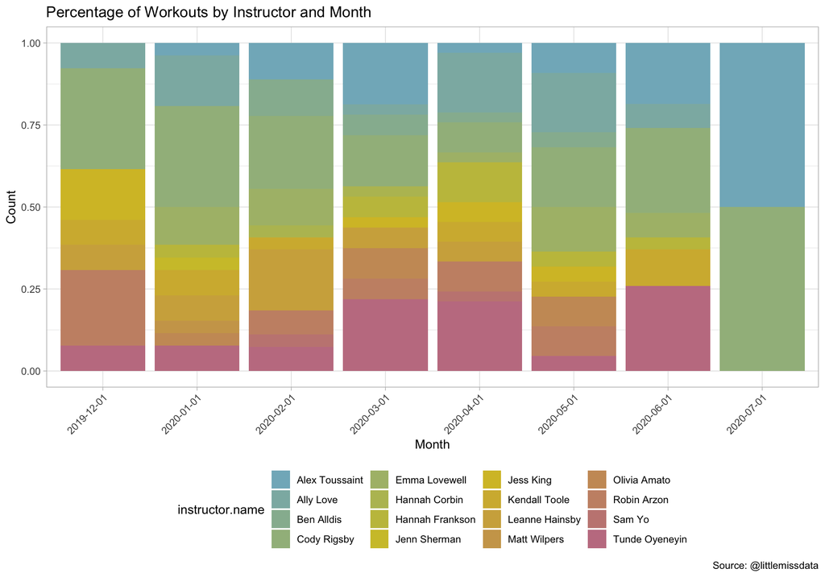

```r
g <- workouts_and_instructors %>%
  dplyr::filter(workout.fitness_discipline =='cycling') %>%
  dplyr::filter(instructor.name !="NA") %>%
  ggplot(aes(x=factor(workout.start_month))) +
  geom_bar(aes(fill = instructor.name), position = 'fill') +
  scale_fill_got(discrete = TRUE, option = "Margaery") +
  theme_light() +
  theme(axis.text.x = element_text(angle = 45, hjust = 1), legend.position="bottom") +
  labs(title = "Percentage of Workouts by Instructor and Month",
       x = "Month", y = "Count",
       caption = 'Source: @littlemissdata')
g
```

#### Density of Workouts per Day of Week and Hour Block

We can plot which days of week and hours of day we tend to work out. The steps below are pretty compact, but the logic is to create the necessary time/date columns with the `mutate` function, filter to only the columns needed with the `select` function, create a summary table of total workouts by hour and day with the`group_by` and `summarize` functions and then create a heatmap with `ggplot` and `geom_tile`.

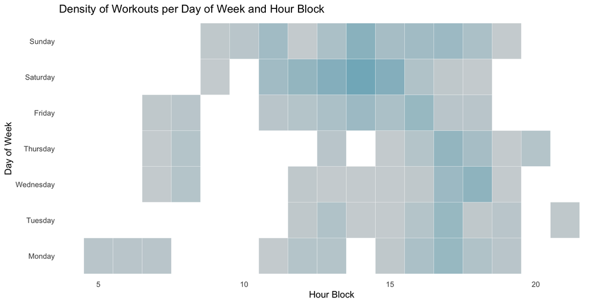

```r
col1 = "#ced4d6"
col2 = "#82B5C4"

workouts_and_instructors %>%
  mutate(workout.start_time_cst = with_tz(workout.start_timestamp,  tzone = "America/Chicago"),
         workout.start_day = wday(workout.start_time_cst, label = TRUE, abbr = FALSE,   week_start = getOption("lubridate.week.start", 1)),
         workout.start_hour = hour(workout.start_time_cst)) %>%
  select (workout.peloton.ride.description, workout.start_day, workout.start_hour) %>%
  group_by(workout.start_day, workout.start_hour) %>%
  dplyr::summarize(N = length(workout.peloton.ride.description)) %>%
  ggplot( aes(workout.start_hour, workout.start_day)) + geom_tile(aes(fill = N),colour = "white", na.rm = TRUE) +
  scale_fill_gradient(low = col1, high = col2) +
  guides(fill=guide_legend(title="Total Incidents")) +
  theme_bw() + theme_minimal() +
  labs(title = "Density of Workouts per Day of Week and Hour Block",
       x = "Hour Block", y = "Day of Week") +
  theme(panel.grid.major = element_blank(), panel.grid.minor = element_blank(), legend.position = "none")
```

# Other Ideas

If you’re trying to think about other cool ideas that you can do with this data, below are a few things which I thought could be neat to do:

- It would be cool to do a [bar race animation chart](https://www.r-bloggers.com/how-to-create-bar-race-animation-charts-in-r/) to show your preferences over time.
- Most of the data sets have some image element (ie `workout.peloton.ride.image_url`and `instructor.instructor_hero_image_url`). I think it would be nice to do a graph with those images used. Possibly in a [scatter plot](https://stackoverflow.com/questions/2181902/how-to-use-an-image-as-a-point-in-ggplot), [or as a background](https://cran.r-project.org/web/packages/meme/vignettes/meme.html) or hopefully something even more creative.
- Add one of the many [giphy peloton stickers](https://giphy.com/search/peloton-stickers) to your graph with the magick package. [Tutorial here](https://www.littlemissdata.com/blog/lacroix)
- I think it would be great to start analyzing more performance based metrics. You could plot `workout.total_work`, `workout.total_video_watch_time_seconds`/`workout.peloton.ride.duration`, any of the difficulty measures or ride times and more.
- Perform a [tidy text](https://www.tidytextmining.com/) analysis on any of the ride or instructor description columns.

# Discover More

At the time of releasing the package, I realized there are a few other Peloton R packages out there. I haven’t had the chance to check them out yet but if you’re looking to round the bases on R Peloton packages, I encourage you to check give them a try. They both seem to have some interesting performance data!

- bweiher/pelotonR
- elliotpalmer/pelotonr

# Thank You

Thank you for trying out my pelotonR package! If you like the package, please share your results with me on [twitter](https://twitter.com/littlemissdata)!